# The "Best" Time (and Places) to Fly: An data-based analysis

## by Maleina Bidek

## Investigation Overview

If you've travelled by air in the United States, you know it can be full of hassles: delays, cancellations, even diversions can really ruin your day. We analyzed flight data over a one year period to identify patterns and answer the following questions:

1. What's the best (and worst) time to fly?
2. What is the best (and worst) combination of airport and carrier if you want to avoid hassles?

## Dataset Overview

Our data set contained 7,009,177 rows and 20 columns of flight arrival and departure details for commercial flights within the United States, including whether or not the flights were cancelled or delayed and what the reason was. It spanned from January through December 2008. The data was obtained from the [American Statistical Society](https://community.amstat.org/jointscsg-section/dataexpo/dataexpo2009).

## What we want to avoid: Cancellations, Delays, Diversions

- Cancellations make up a small percentage of flights (1.96%)
- Diversions are even rarer (0.24%)
- Delays are unfortunately quite common (21.75%)
- Still, more than 3/4 flights are on-time (defined as no more than 15 minutes late)
- Because our dataset contains information about the causes of cancellations and delays, but not diversions, we will focus our analysis on avoiding the first two.

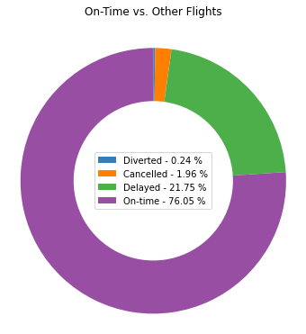

## What is causing all of these delays?

- National Aviation System (NAS) delays are the most common. Late aircraft and carrier delays are virtually tied for second place. Security delays are relatively rare.
- However, late aircraft result in the most the most delay hours in total across all flights.
- Even though there are comparatively few weather delays in total, they take the longest on average when compared to the other types. Both weather and late aircraft delays take on average more than 40 minutes, while security delays take the least average amount of time (less than 20 minutes).

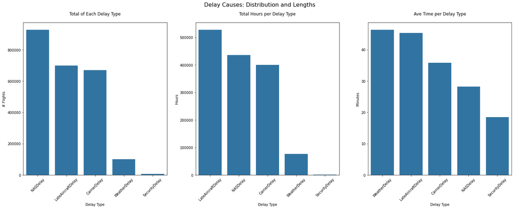

## What causes cancellations?

- The percentage of cancellations due to weather and carrier issues were almost equal (39.95% and 39.53% respectively).
- There are relatively few cancellations due to security reasons (0.01%).

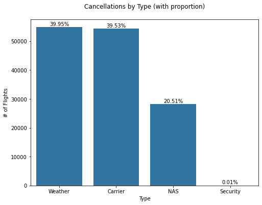

### When is the best (and worst) time to fly?

Next, we'll look at how to avoid cancellations and delays by:

- Time of year
- Time of day
- Day of week

### Avoiding cancellations by season

It may seem obvious, but if you're worried about cancellations, avoid flying during the winter months. They are proportionally higher in January, February, March and December.

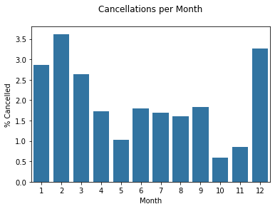

### Avoiding delays by season

Delays, on the other hand, are common throughout the year, but are lowest in the fall (September, October and November). The next best months are April, May and August.

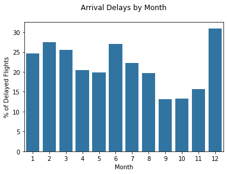

### What is the best day and time to avoid cancellations?

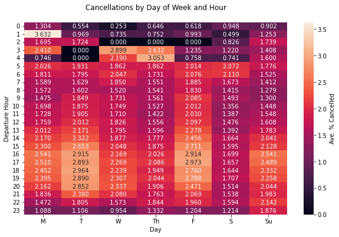

### What is the best day and time to avoid delays?

- Departures in the 4am hour on Thursdays are on average a whopping 182 minutes late on arrival.
- BUT given that there are relatively few flights at this time (only 11 in total!), a couple of big delays of over 400 minutes look like they skewed our results.
- The important take away is that there's not a lot of variation in official arrival delays in general across day and time, with the exception of the early morning hours.

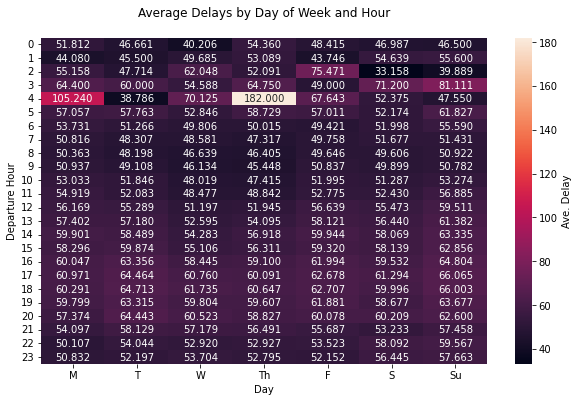

### When is the best day and time to fly for an on-time arrival?

- Based on this dataset, if you want to arrive to your destination early, the best time to fly is on Tuesdays at around 4am. (The caveats above apply.)
- Again, there is a lot of variation in the early morning hours. This may due to the fact that there are relatively few fights at these hours, which leave them susceptible to skewing.
- In general, however, early and on-time arrivals to tend to occur in the morning hours.
- Friday, Sunday and Thursday evenings show the biggest delays (positive differences between actual and scheduled arrival times.)

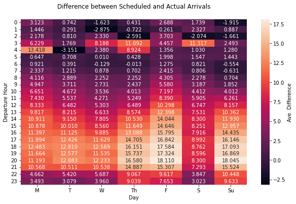

### Which airports have the most cancellations?

- Small or regional airports tend to have a higher percentage of cancellations.

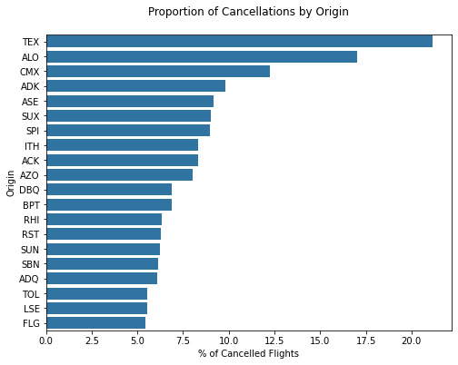

### Which airports have the most delays?

- Pueblo, Colorado (PUB) tops the list, but that airport only had two flights!
- In general, though, small or regional airports tend to have a higher percentage delays.
- Newark (EWR) was the top large airport in the list. Miami, Chicago O'Hare, New York JFK, and New York LaGuarida are also in the list.

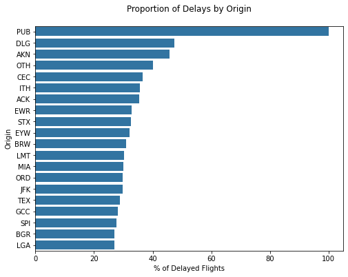

### Which airline had the most cancellations?

- Smaller regional airlines Envoy Air (MQ) and Mesa Airlines (YV) had the largest proportion of cancellations.
- Large airlines such as American (AA) and United (UA) were in the top half.
- Discount airline Southwest (WN) and the former major airline Northwest (NW) were in the bottom third.
- Smaller regional carrier Frontier (F9) had the lowest proportion of cancellations.

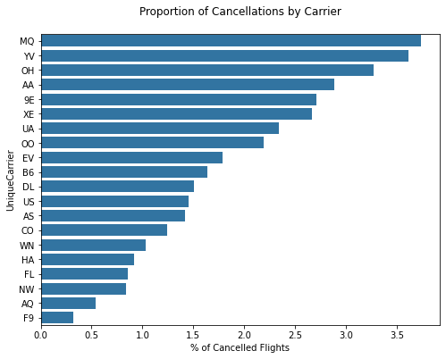

### Which airline had the most delays?

- American airlines tops the list with more than a quarter of their flights being delayed!
- United is the next large carrier on the list with approximately 25% delayed flights.
- Small carrier 9 Air Company (AQ) had the lowest percentage of delays (5%).

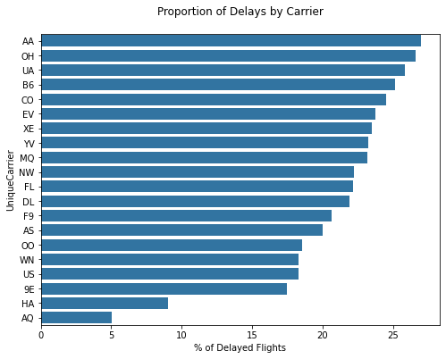

### Best (and worst) airport and carrier combination to avoid hassles

- The winning combination is flying with 9 Air Company (AQ) and departing from Las Vegas (LAS). (A negative delay means on average flights arrived early!)
- The worst combination in our set was the now defunct Continental Airlines (CO) departing from Charlotte (CLT).
- When looking for consistently good performance across airports, U.S. Airways (US) had the best record. Unfortunately, they no longer exist.

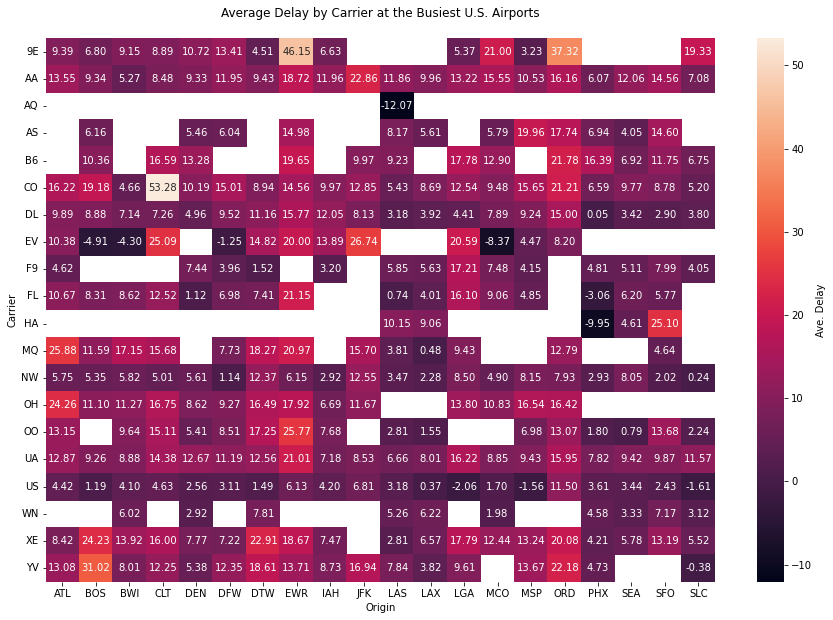

### Next Steps

We should continue this analysis on a larger, more recent set. This will be especially helpful for analyzing some of the patterns we saw at flight times with a relatively low volume of flights, i.e. early mornings.